# B3_1: odin basics & the SIR model

## B3_1: odin basics & the SIR model

Coding compartmental models with R and odin

Swapnil Mishra (Asst. Professor)

Session book: notes, exercises and solutions

## Before we start: setup

You need R (≥ 4.1) and a C compiler:

- macOS: `xcode-select --install`
- Windows: [Rtools](https://cran.r-project.org/bin/windows/Rtools/)
- Linux: `gcc` is usually already present

Then install the packages (odin plus its compile-time helpers):

```r
install.packages(c("odin", "pkgbuild", "pkgload"))
```

Check that everything works — this compiles a small test model:

```r
odin::can_compile()
```

```
#> [1] TRUE
```

## How to follow along

1. Create a new project: *File → New Project → New Directory → New Project*
2. Open a new R script: *File → New File → R Script*
3. Paste each code chunk there as we go and run it

The book page has all the code with notes and solutions: https://cerm-nus.github.io/odin-example/lectures/01-odin-basics-sir.html

## Why odin?

A compartmental model is a set of ordinary differential equations (ODEs).

- R’s standard solver, `deSolve`, integrates these with compiled Fortran routines — the solver itself is fast
- The slow part is the model function: you write it in R, and the solver calls back into R at every integration step
- You can write the model function in C (deSolve supports this), but doing it by hand is tedious and easy to get wrong

odin does this translation for you:

- You write the equations in a language that looks like R
- odin translates them to C, compiles them, and links them to deSolve’s solver
- The model runs at compiled speed — this matters when you fit models or run many scenarios
- odin also handles the bookkeeping: state vectors, initial conditions, array indexing

## The declarative idea

odin code is declarative. It is not executed as R code; it is parsed and compiled. You write what the equations are, not how to compute them, so the order of the lines does not matter.

## The SIR model

The classic SIR model splits a population of $N$ people into Susceptible, Infectious and Recovered:

$$\frac{dS}{dt} = -\beta SI, \qquad
\frac{dI}{dt} = \beta SI - \gamma I, \qquad
\frac{dR}{dt} = \gamma I$$

- $\beta$ — transmission rate
- $\gamma$ — recovery rate; $1/\gamma$ is the mean infectious period
- The basic reproduction number is $R_0 = \beta N / \gamma$

This is the density-dependent formulation: transmission is proportional to the number of infectious people, so $R_0$ scales with the population size $N$ — and $\beta$ therefore depends on the population you are modelling.

## Anatomy of an odin model

An odin model has three ingredients: derivatives (`deriv()`), initial conditions (`initial()`) and parameters. In this first version we fix the parameter values directly in the code:

```r
library(odin)

# verbose = TRUE so we can watch odin generate and compile the C code
sir_generator <- odin::odin({
  deriv(S) <- -beta * S * I
  deriv(I) <- beta * S * I - gamma * I
  deriv(R) <- gamma * I
  initial(S) <- N0 - I0
  initial(I) <- I0
  initial(R) <- 0
  N0    <- 1000  # total population size
  I0    <- 1     # initial number infectious
  beta  <- 2e-4  # transmission rate (R0 = beta * N / gamma = 2)
  gamma <- 0.1   # recovery rate (10-day infectious period)
}, verbose = TRUE)
```

```
Generating model in c
```

```
ℹ Re-compiling odin09448d67 (debug build)
```

[output not shown]

```
ℹ Loading odin09448d67
```

## What just happened?

The messages show odin generating C code from the equations and compiling it. From this point on, running the model involves no R code at all.

The compiler warnings you may see (`unused variable`, `format specifies...`) come from the C template inside the odin package — odin regenerates it on every compile, so there is nothing in your model to correct. They sit in code paths this model never hits; the place to fix them is upstream in odin.

Note two things:

- `odin::odin({...})` parsed and compiled the equations. If that line runs without error, the model is ready to use.
- The result, `sir_generator`, is not a model — it is a model generator: a factory that creates model instances.

## Running the model

Create an instance and run it over a vector of times:

```r
sir <- sir_generator$new()

times <- seq(0, 150, by = 1)   # daily output over 150 days
out <- sir$run(times)

head(out)
```

```
     t        S        I         R
[1,] 0 999.0000 1.000000 0.0000000
[2,] 1 998.7899 1.104927 0.1051592
[3,] 2 998.5578 1.220810 0.2213507
[4,] 3 998.3015 1.348781 0.3497250
[5,] 4 998.0184 1.490086 0.4915513
[6,] 5 997.7057 1.646096 0.6482319
```

## Plotting with ggplot2

```r
as.data.frame(out) |>
  pivot_longer(c(S, I, R), names_to = "compartment", values_to = "n") |>
  ggplot(aes(t, n, colour = compartment)) +
  geom_line(linewidth = 1) +
  scale_colour_manual(values = c(S = "#0072B2", I = "#D55E00", R = "#009E73")) +
  labs(x = "Time (days)", y = "Number of people", colour = NULL) +
  theme_classic(base_size = 16) +
  theme(legend.position = "bottom")
```

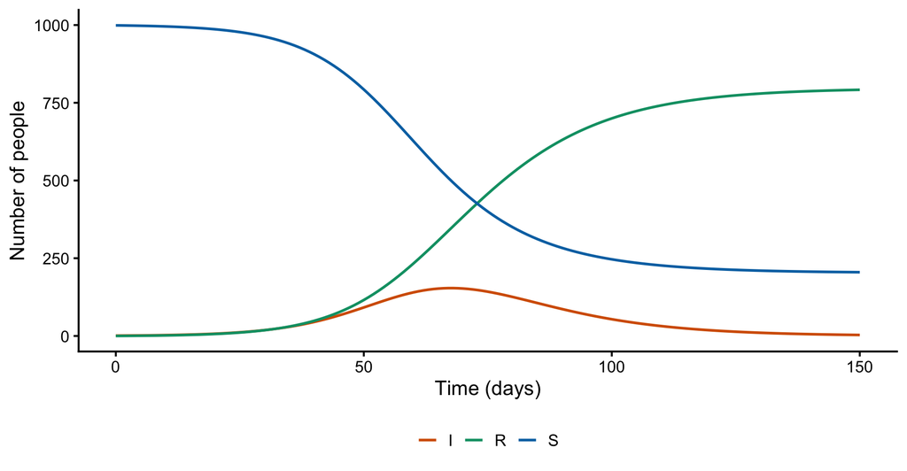

Here $R_0 = \beta N / \gamma = 2$.

## Making parameters changeable: `user()`

This model works, but the parameters are fixed in the compiled C code. To try a different `beta` you would have to edit the model definition and recompile, which gets awkward when you want to compare several scenarios.

`user()` solves this. Declaring a parameter with `user(default)` makes it settable when the model instance is created, with the default used when you don’t set it. Only the parameter block changes:

```r
sir_generator <- odin::odin({
  deriv(S) <- -beta * S * I
  deriv(I) <- beta * S * I - gamma * I
  deriv(R) <- gamma * I
  initial(S) <- N0 - I0
  initial(I) <- I0
  initial(R) <- 0
  N0    <- user(1000)  # can now be changed at $new() time
  I0    <- user(1)
  beta  <- user(2e-4)
  gamma <- user(0.1)
})
```

[output not shown]

- `sir_generator$new()` uses all the defaults.
- `sir_generator$new(beta = 3e-4)` overrides just `beta`, without recompiling — the compiled C code is reused.
- `mod$contents()` shows the parameter values an instance is using.

## One generator, many scenarios

Scenarios are now cheap — pass new parameter values to `$new()`:

```r
beta_values <- c(3e-4, 2e-4, 1.5e-4)
scenario_runs <- list()                 # one run per beta value
for (i in seq_along(beta_values)) {
  scenario_runs[[i]] <- sir_generator$new(beta = beta_values[i])$run(times)
}
```

Compilation happens once; every scenario after that is just `$new()` and `$run()`.

## Scenarios: the epidemic curves

```r
cols <- hcl.colors(length(beta_values), "Berlin")
scenario_labels <- paste("beta =", beta_values,
                         "(R0 =", beta_values * 1000 / 0.1, ")")
scenario_data <- bind_rows(lapply(seq_along(beta_values), function(i) {
  as.data.frame(scenario_runs[[i]]) |>
    mutate(scenario = scenario_labels[i])
})) |>
  mutate(scenario = factor(scenario, levels = scenario_labels))

ggplot(scenario_data, aes(t, I, colour = scenario)) +
  geom_line(linewidth = 1) +
  scale_colour_manual(values = setNames(cols, scenario_labels)) +
  coord_cartesian(ylim = c(0, 350)) +
  labs(x = "Time (days)", y = "Infectious (I)", colour = NULL) +
  theme_classic(base_size = 16) +
  theme(legend.position = "bottom")
```

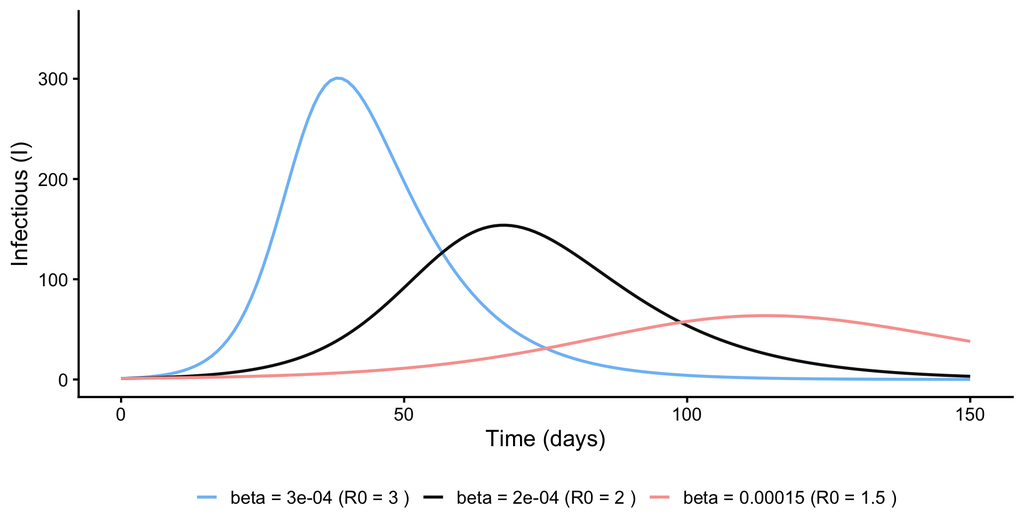

Peak prevalence falls as transmission slows.

## Notes on scenarios

- Only the parameters you name are changed; the rest keep their defaults
- No recompilation needed — the C code is compiled once, at generator creation

## Tracking extra quantities: cumulative incidence

Sometimes you want a quantity that is not a compartment — for example the total number of infections so far. Add another derivative that accumulates it:

```r
sir_inc <- odin::odin({
  deriv(S) <- -beta * S * I
  deriv(I) <- beta * S * I - gamma * I
  deriv(R) <- gamma * I
  deriv(cum_inc) <- beta * S * I   # accumulates new infections
  initial(S) <- N0 - I0
  initial(I) <- I0
  initial(R) <- 0
  initial(cum_inc) <- 0
  N0    <- user(1000)
  I0    <- user(1)
  beta  <- user(2e-4)
  gamma <- user(0.1)
})
```

[output not shown]

## The final size of the epidemic

```r
out <- sir_inc$new()$run(times)
as.data.frame(out) |>
  ggplot(aes(t, cum_inc)) +
  geom_line(linewidth = 1) +
  labs(x = "Time (days)", y = "Cumulative infections") +
  theme_classic(base_size = 16)
```

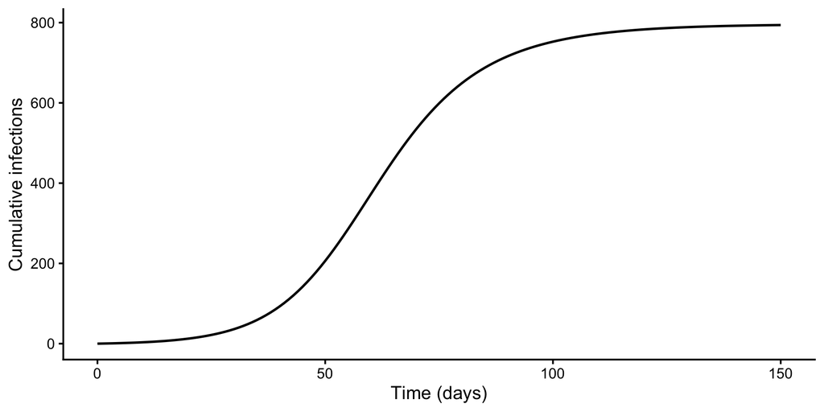

## Exercise 1

**Exercise 1.1 — What does $R_0$ control?** Using `sir_generator`, run the model with `beta` chosen so that $R_0$ is 1.2, 1.5 and 2.5 (keep `gamma = 0.1`; remember $R_0 = \beta N / \gamma$). Plot the three `I` curves on one plot. What happens to the peak height and peak timing as $R_0$ increases?

**Exercise 1.2 — Threshold behaviour** Set `beta = 8e-5` (so $R_0 = \beta N / \gamma = 0.8 < 1$) and run the model. What happens, and why does no epidemic occur?

## Recap

- odin models are equations, not code: `deriv()`, `initial()`, parameters
- `odin::odin({...})` compiles the equations to C and returns a generator
- `generator$new()` creates an instance; `$run(t)` integrates it
- `user(default)` makes a parameter settable at `$new()` — one compilation, unlimited scenarios
- Add a `deriv()` line for derived quantities like cumulative incidence

**Next:** Lecture 2 — B3_2 slides: extending models — SEIR, demography & time-varying parameters

Session book: notes, exercises and solutions